# Task3

Tomas Kozlovskis

Tuesday, March 15, 2016

Futbolas. (Iššūkis) Modeliuokime fotbolo varžybų metu įmašumų įvarčių kiekį. Laiko intervalai tarp įvarčių modeliuojami su eksponentiniu skirstiniu (eksponentinio skirstinio parametrą pasiūlykite patys). Kaip tuomet atrodo įvarčių pasiskirstymas varžybų tėkmėje? Taip pat pažiūrėkite kokį skirstinį turi varžymų bagties skirstinys. Ar tai primena Poisono skirstinį? Ar galite atlikti formalų testą?

Pradėkime nuo įvarčių, įmuštų per rungtynes skaičiaus generavimo.

```r
goalspg <- function() #Ivarciu per vienas rungtynes
{
  x<-0
  y<-rexp(100, 0.034)
  i<-1
  while(x<90)
  {
    if(x + y[i] <= 90)
      x <- x + y[i]
    else
    {
      y = y[-i]
      x = 90
      i = i - 2
    }
    i = i + 1
  }
  return(i)
}
```

Kuomet turime funkciją, kuri generuoja, kiek įvarčių buvo imušta per vieneres rungtynes, galime sugeneruoti daug stebejimų, ir pasižiūrėti kaip atrodo įvarčių pasiskirstymas per 1000 rungtynių.

```r
goalsp1000<-replicate(1000, goalspg())
```

Šiuo atveju išspausdinsime pirmus 100 stebėjimų:

```
##   [1]  1  3  4  1  1  4  5  4  2  0  4  3  4  4  3  3  2  0  3  6  4  5  0
##  [24]  0  3  4  7  5  2  7  3  4  3  4  3  2  0  3  4  4  1  0  4  2  2  4
##  [47]  4  0  3  3  2  3  3  3  2  1  2  5  1  1  0  2  2  3  1  2  4  2  2
##  [70]  5  4  2  6  1  3  0  1  1  2  1 11  4  2  3  1  4  1  4  1  1  2  2
##  [93]  1  2  3  2  3  6  3  3
```

Įvarčių sklaidos diagrama ir histograma atrodo taip:

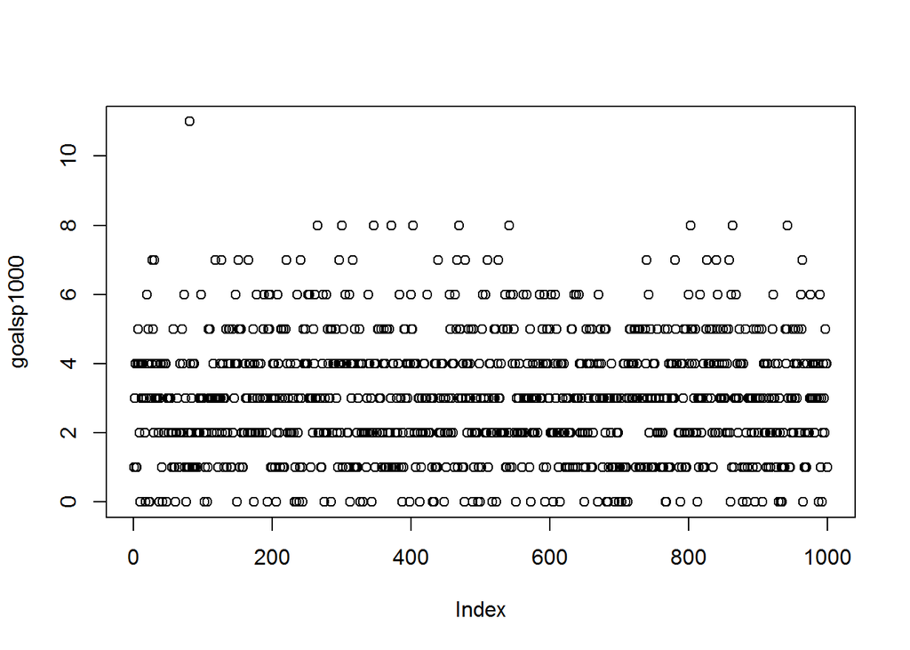

```r
plot(goalsp1000)
```

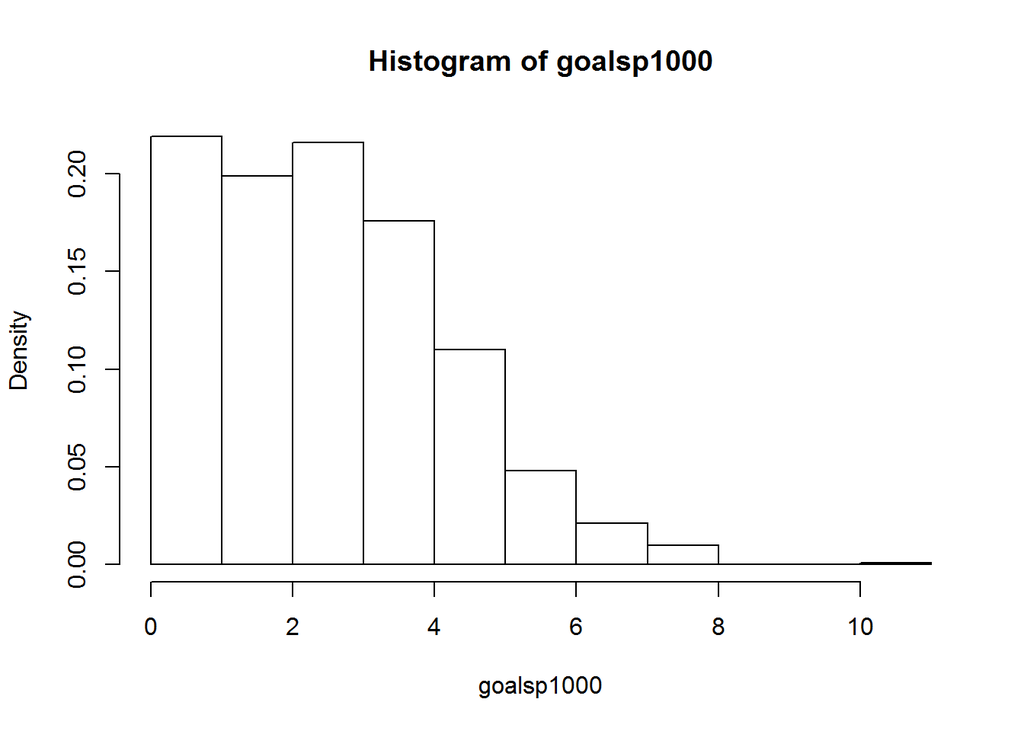

```r
hist(goalsp1000, probability=TRUE)
```

Histograma rodo, jog įvarčių pasiskirstymas tikrai nėra normalus. Taigi, reikia patikrinti, ar įvarčių pasiskirstymas yra panašus į Poissono skirstinį.

Viena iš Poissono skirstinio savybių yra tai, jog jo vidurkis ir dispersija yra lygūs.

```r
mean(goalsp1000)
```

```
## [1] 2.979
```

```r
var(goalsp1000)
```

```
## [1] 3.105665
```

Vidurkis yra beveik lygus dispersijai, bet visgi bet kokiu atveju, ši savybė nėra pakankama tam, kad galėtume įrodyti, jog įvarčiai yra pasiskirstę pagal Poissono skirstinį.

Todėl naudoju Kolmogorovo-Smirnovo testą, kuris tikrina ar dvi imtys yra pasiskirsčiusios pagal tą patį skirstinį. Sugeneruoju imtį pagal Poissono pasiskirstymą ir lyginu ją su įvarčių pasiskirstymo imtimi.

```r
ps<-rpois(1000, 3)
ks.test(goalsp1000, ps)
```

```
##
##  Two-sample Kolmogorov-Smirnov test
##
## data:  goalsp1000 and ps
## D = 0.029, p-value = 0.7944
## alternative hypothesis: two-sided
```